# Introduction to the Test Case Variables 1

### This topic applies to both homework notebooks and exams.

### In these videos, we are introducing the testing paradigm that is universal throughout the course.

You have already seen this paradigm in Homework Notebook 0, and these videos go into detail on what to expect and how to work with it.

# Note that all exercises in the course, on all homeworks and exams, have an "ALL OR NOTHING" scoring.

# So your exercise solution is either 100% correct and you get full points, or it is not, and you receive 0 points.

# There is no "PARTIAL CREDIT" for any exercise in this course, period.

## Exercise Process Flow

### Let's look at the flow of writing functions in python in a little more detatil, to understand the process. The below diagram summarizes what a 'typical' flow of writing functions should look like, **for both homework notebooks and when you are taking the exams in this course.**

Each homework notebook and exam exercise will require students to write a function by taking inputs, processing them in some way, and generating outputs.

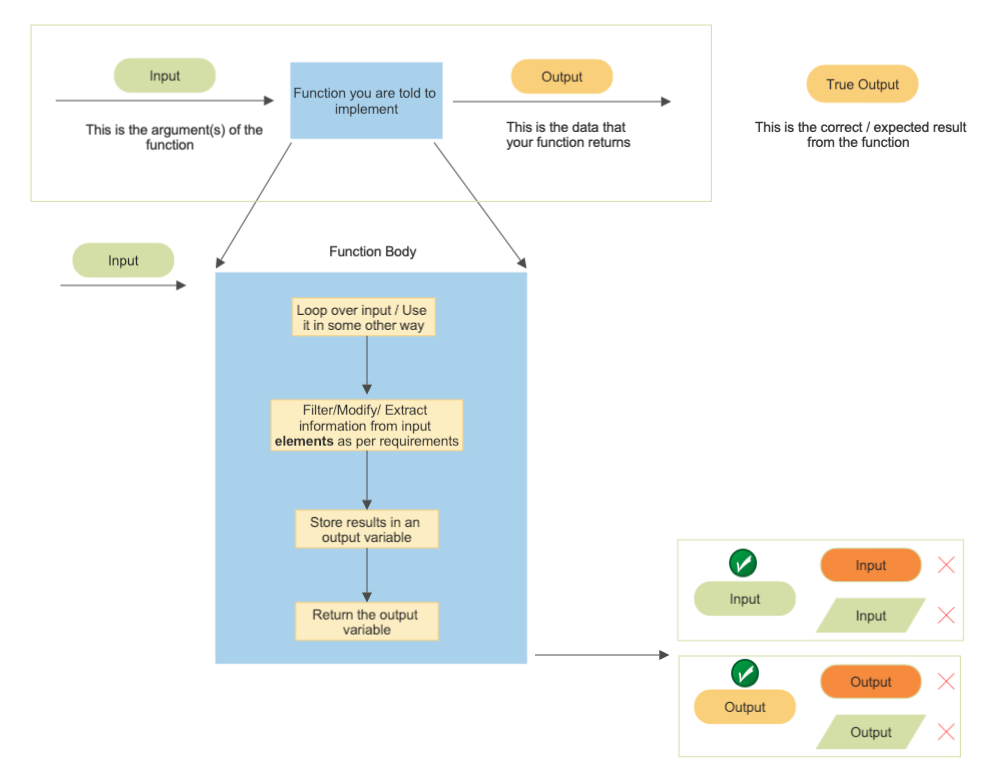

### From the above diagram, you can see that the process is as follows:

1. You will be provided one or more inputs to the function.
2. You will write your function by processing the inputs in some manner.
3. You will **return** outputs from your function
4. The **test cell** will compare your outputs to the solution outputs to determine if your function has worked correctly.

```python
def sample_function(_input):
    ###YOUR CODE HERE

    return my_returned_output
```

### The test cell will perform two tests:

1. Test to ensure that your function does not modify any of the input variables. This performs an evaluation of the actual code in your function for this test case.
2. Test to compare your function output against the `true output`, which is the answer to the exercise. This tests the actual output of your function.

#### Both tests must pass in order for you to receive the points for the exercise.

## So how do the exercises actually work?

#### Here is how each exercise is organized. We will go through an example, from Homework Notebook 1, in the next notebook for this session.

### Exercise Pattern

1. There will be a discussion of exercise context, within the overall analysis process.
2. Next will be the exercise requirements, or the problem that the exercise is solving for, again in the context of the overall analysis.
3. Then we will see the details of the inputs and outputs. This is actual data definition of what will come into the function and what the function will output, including the data structures and data types of each.
4. A recommended methodology for solving the exercise ***MAY*** be provided. If such a methodology is provided, we ***HIGHLY ENCOURAGE*** the students to use the methodology steps to solve the exercise. In most every case, the methodology will provide a step by step pseudocode solution for the exercise.
5. Additionally, one or more ***HINTS MAY BE PROVIDED.*** If a hint is provided, it is ***100% INTENDED*** for the student to use the hint to solve the exercise. You would be well served to include the hint in your solution.
6. There will be some demo input provided, along with what the expected output will be, for this demo input. ***This is designed to give you some sample data, to help you to get your code up and running. You will see these for every exercise on all of the exams. Note that passing the demo cell DOES NOT MEAN that your solution is 100% correct and you will receive full points in testing. The demo cell provides a limited data set the does not cover all possible solution cases.***
7. The next cell of the notebook will be the actual exercise cell, for students to write their code in. The last line of the cell may call your function with the demo input, so that you can test your function as you are writing it.
8. Then there will be a cell which calls the function using the demo input, for the student to test with, while developing the function. If the last line in the function cell is for demo testing, then this cell will not be there.
9. Next will be an explanation of the test cell, and the testing paradigm. This explanation is the same for every exercise.
10. Finally, the test cell will test the function and output a testing result.

## One final note, concerning the demo cells.

### The demo cells are designed to give you some sample data, to help you to get your code up and running. You will see these for every exercise on all of the exams.

## Note that I can pass the demo cell and still fail the test cell!!!

This will be ***ONE OF THE BIGGEST PROBLEMS*** for students on the exams.

Students think that, because they passed the DEMO CELL, it means that they WILL ALSO pass the TEST CELL.

This IS NOT the case, as the DEMO CELL is designed to give you some SAMPLE DATA, to help you get your code up and running.

## The DEMO CELL IS NOT a full test of your code, and you can easily pass the DEMO CELL and FAIL the TEST CELL!!!

## The TEST CELL is a FULL TEST of your code, and it is much more extensive than the DEMO CELL.

## So be aware that you can pass the DEMO CELL and still fail the TEST CELL.

***ON EVERY EXAM***, there will be* **AT LEAST 20 Piazza posts*** from students whose code passes the demo cell and fails the test cell. They will post that there is a BUG in the exam because of this, when in fact, their code is incorrect.

Please be aware of this difference between the demo and test cells.